# Bootstrap implied Bayes inference

Brian Caffo, Martin Lindquist, Ciprian Crainiceanu, Vadim Zipunnikov

11/28/2017

## Introduction

Consider observed outcome data $y=(y_1, \ldots y_n)$ arising from density $f_y(y; \theta, \psi)$ depending on parameter of interest $\theta$ and nuisance parameter, $\psi$. Let $b = (b_1, \ldots, b_n)^t$ be a bootstrap resample. For example, $b = (b_1, \ldots, b_n)^t = (w_1^t y_1 \ldots w_n^2 y_n)$ where $w_i \sim_{iid} f_w$ where $f_w$ is a resampling distribution. This could be described as linear bootstrap resampling in that it assumes a useful empirical distribution can be obtained by linearly resampling or reweighting the observed data. The classic non-parametric bootstrap sets $f_w$ as a multinomial distribution with one trial and equal category probabilities. Other resampling schemes might directly employ $f_y$ or other residual or parametric strategies. Our approach is largely agnostic to sampling strategy.

Let $s$ be a statistic so that $\theta^* = s(b)$ is a bootstrapped resampled statistic having density $f_{\theta^*}(\theta)$. Let $\pi(\theta, \psi)$ be a joint prior. We are interested in conditions in which $f_{\theta^*}(\theta)$ can be considered a posterior marginalized over nuisance parameters. That is,
$$\dagger ~f_{\theta^*}(\theta) = \pi(\theta ~|~ y) = \frac{\int f_y(y; \theta, \psi) \pi(\theta, \psi) d\psi}{\int \int f_y(y; \tilde \theta, \tilde \psi) \pi(\tilde \theta, \tilde \psi) d\tilde \psi d\tilde \theta} = \int f_y(y; \theta, \psi) \pi(\theta, \psi) / C,$$
where $C$ is the normalizing constant.

The left hand side of this equation depends on the bootstrap sampling distribution (such as choice of $f_w$) and $s$ (the statistic), whereas the right hand side depends on $f_y$ (the likelihood) and $\pi$ (the prior). Choose any three and the fourth is determined, assuming a solution to the equation exists for the choices.

It is easy to conceptualize instances where this equality necessarily fails; not every marginal posterior arises from a proper prior given a likelihood. Several examples where improper priors are obtained are given below. In addition, when using the non-parametric bootstrap, one obtains a prior distribution depending on the data, truly violating the nature of the approach. Finally, the statistic might produces estimates outside of the range of the parameter, such as negative variance components, which will clearly yield no acceptable solution to $\dagger$.

While this potential identity is interesting in its own right, we are primarily interested in calculating an associated prior from the bootstrap sampled distribution. Thus, given a bootstrap distribution associated with resampling one could postulate a likelihood and see the prior that would result in equivalent inference. Such a process would allow one to employ Bootstrap analyses and allow one to interogate Bayesian statements presuming a choice of likelihood.

In addition, settings for which this equation holds may have large pedagogical advantages by yielding equivalent Bayesian and frequency inferences within the same framework. In other words, one could teach a fairly unified variation of statistic using the bootstrap, a technique already of fundamental importance in introductory statistics instruction.

The approach derives heavily from Efron (2012) (BIATPB), with some notable differences. First, BIATPB considers only parametric settings, whereas we also consider non-parametric settings. Secondly, the primary goal of BIATPB is to produce Bayesian inferences via the bootstrap. Our consideration is more holistic. We are interested in general in connections between Bayesian inference and the bootstrap. In this manuscript, we focus on discovering the prior given a bootstrapping scheme, statistic and likelihood.

Newton and Raftery (1994) have an approach similar to ours, utilizing a weighted likelihood version of the bootstrap. However, our approach is more directly related to non-parametric bootstrap sampling as it’s implemented.

Rubin presented a Bayesian bootstrap (Rubin and others 1981) where the empirical probability distribution was simulated as a Dirichlet mixture of multinomials. That is, $F_w$ was simulated as a multinomial$(d,1)$ with probability vector $d$ simulated via a Dirichlet.

### Bootstrap integrated likelihood relationship

Given the relationship given by $\dagger$, we have:
$$\dagger \dagger ~~ f_{\theta^*}(\theta) = \pi(\theta) \int f_y(y; \theta, \psi) \pi(\psi ~|~ \theta) d\psi / C
= \pi(\theta) {\cal L}(\theta; y) / C,$$
where
$${\cal L}(\theta) = \int f_y(y; \theta, \psi) \pi(\psi ~|~ \theta) d\psi$$
is the integrated likelihood (see Berger et al. 1999). In the event that there is no nuisance parameter, then the integrated likelihood is simply the likelihood.

Thus, one can solve for the prior or integrated likelihood as:
$${\cal L}(\theta; y) \propto_\theta \frac{f_{\theta^*}(\theta)}{\pi(\theta)} ~~~\mbox{or}~~~ \pi(\theta) \propto_\theta \frac{f_{\theta^*}(\theta)}{{\cal L}(\theta; y)}$$

We will see that it is useful use binning to calculate $f_{\theta^*}(\theta_k)$ for $k=1,\ldots,K$ discrete values of $\theta$. Define bins $a_0, a_1, \ldots, a_K$ and let $p_k$ be the count of $a_{k-1} < \theta_j^* \leq a_k$ for $k=1,\ldots,K$. Let $\theta_k = (a_k - a_{k-1})/2$ be the bin midpoints. While the histogram, $(\theta_k, p_k)$ is a reasonable density estimate for $f_{\theta^*}$, a better estimate smooths them, or perhaps logs the probabilities before smoothing (Eilers and Marx 1996). Our approach fits a smooth Poisson GAM to the bincounts (as in Eilers and Marx 1996). Regardless, assuming that the $p_k$ are the bin probabilities, the estimate of the integrated likelihood or prior is:
$${\cal L}(\theta_k; y) \propto_\theta \frac{p_k}{\pi(\theta)} ~~~\mbox{or}~~~ \pi(\theta_k) \propto \frac{p_k}{{\cal L}(\theta_k; y)}.$$

When calculating for the prior, paradoxically, the estimated prior depends on the data. Thus, it is important to emphasize the question this technique answers: “Approximately what prior would have given me this posterior?”, rather than “What is a good prior for this data/likelihood?”. It is also worth emphasizing that the conditional prior $\pi(\psi ~|~ \theta)$ and likelihood are required to calculate the integrated likelihood. In the event that the integrated likelihood, ${\cal L}$, cannot be calculated analytically, if $\pi(\psi ~|~ \theta)$ can be simulated from, an estimate can be obtained via: $p_k \frac{1}{N} \sum_{j} f_y(y; \theta_k , \psi_j).$

Similarly, when calculating for the integrated likelihood, it also should be stressed that no guarantees can be given that resulting function corresponds to an actual integrated likelihood that one would reasonably fit to data. If one wants the actual likelihood, a prior for $\pi(\psi ~|~ \theta)$ is required as well as a solution to the inverse problem. This approach simply answers the question “What integrated likelihood combined with this prior would yield my bootstrapped statistics distribution?”.

A benefit of treating the parameter distribution as discrete is that equation $\dagger$ will necessarily always hold, provided one does not put positive probability in the bootstrap distribution on values outside of the support. Continuous approximations could also be used, though will require either a parametric bootstrap sampling procedure or an interpolated estimate of $f_{\theta^*}$. This seems unnecessary given the goals of the procedure. Specifically, one wants to loosely interrogate Bayes models related to the bootstrap results.

## Examples

In this section, we give analytic examples of bootstrap concordance with Bayesian inference. Subsequently, we numerically evaluate these examples.

### Estimation of the mean

Consider the instance where $y_i \sim N(\mu, 1/\psi)$ and $\pi(\psi ~|~ \mu) = \pi(\psi)$ is Gamma$(\alpha_0, \beta_0 / 2)$. Then the integrated likelihood is proportional to $\left(\sum_{i=1}^n (y_i - \theta)^2 + \beta_0\right)^{-n/2 - \alpha}$. Let $p_k$ be the estimated bootstrap probability associated with $\theta_k$. Then the associated prior is:

$$\pi(\theta_k) \propto p_k \left(\sum_{i=1}^n(y_i - \theta_k)^2 + \beta_0\right)^{n/2 +\alpha}$$

More easily, if the prior is $\pi=N(\mu_0, 1/\tau_0)$ then the estimated integrated likelihood is

$$p_k \exp\left\{\frac{1}{2}(\theta - \mu_0)^2 \tau_0\right\}.$$

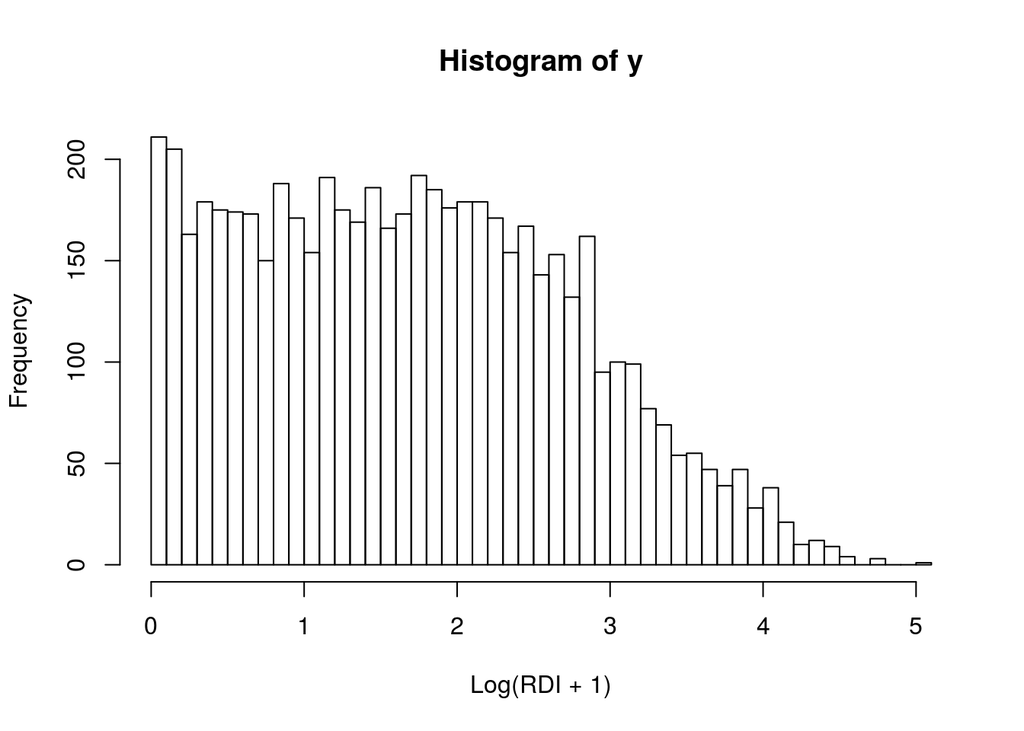

```r
dat = read.table("shhs1.txt", header = TRUE) %>% mutate(y = log(rdi4p + 1))
#ggplot(dat, aes(y)) + geom_histogram() + xlab("log(RDI + 1)")
y = dat$y
hist(y, breaks = 50, xlab = "Log(RDI + 1)")
```

Now lets perform the bootstrap.

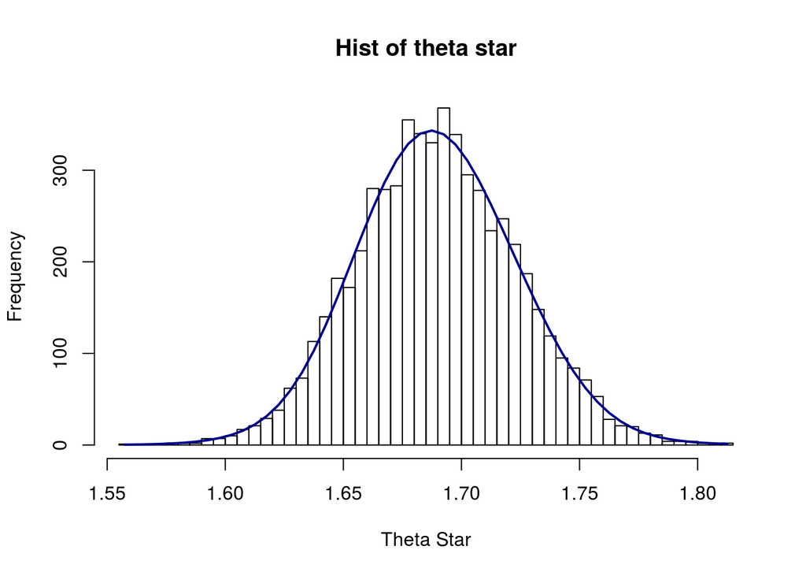

```r
n = length(y); B = 1000
## perform the bootstrap
thetaStar = apply(matrix(sample(y, n * B, replace = TRUE), n, B), 1, mean)
## raw histogram
h = hist(thetaStar, breaks = 50, xlab = "Theta Star", main = "Hist of theta star")
## smoothed histogram
theta = h$mids; p = h$counts
fit.smooth = gam(p ~ s(theta), family = "poisson")
phat = predict(fit.smooth, type = "response")
lines(theta, phat, lwd = 2, col = "darkblue")
```

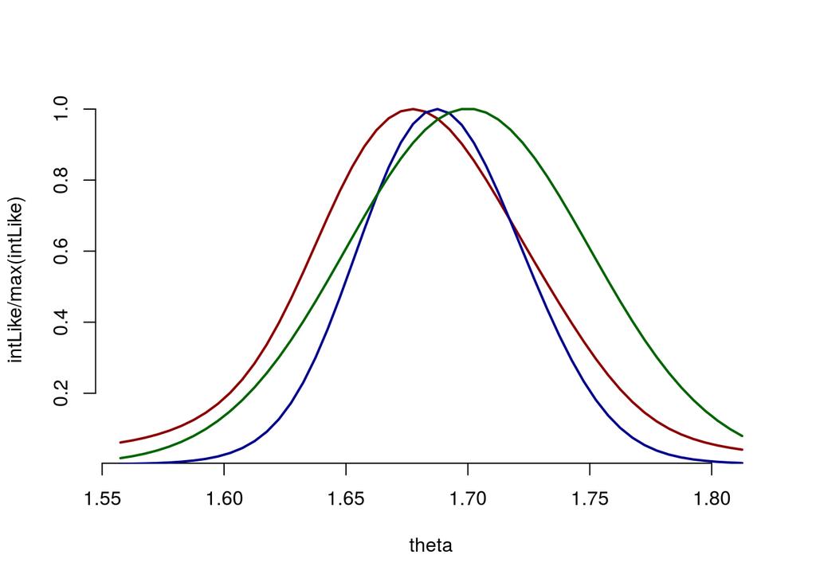

```r
mu0 = 1.7; sigma0 = 0.05
prior = dnorm(theta, mean = mu0, sd = sigma0)
intLike =  phat / prior
plot(theta, intLike / max(intLike),
     type = "l",
     col = "darkred",
     lwd = 2,
     frame = FALSE)
lines(theta, phat / max(phat), lwd = 2, col = "darkblue")
lines(theta, prior / max(prior), lwd = 2, col = "darkgreen")
```

## References

Berger, James O, Brunero Liseo, Robert L Wolpert, and others. 1999. “Integrated Likelihood Methods for Eliminating Nuisance Parameters.” *Statistical Science* 14 (1). Institute of Mathematical Statistics: 1–28.

Efron, Bradley. 2012. “Bayesian Inference and the Parametric Bootstrap.” *The Annals of Applied Statistics* 6 (4). NIH Public Access: 1971.

Eilers, Paul HC, and Brian D Marx. 1996. “Flexible Smoothing with B-Splines and Penalties.” *Statistical Science*. JSTOR, 89–102.

Newton, Michael A, and Adrian E Raftery. 1994. “Approximate Bayesian Inference with the Weighted Likelihood Bootstrap.” *Journal of the Royal Statistical Society. Series B (Methodological)*. JSTOR, 3–48.

Rubin, Donald B, and others. 1981. “The Bayesian Bootstrap.” *The Annals of Statistics* 9 (1). Institute of Mathematical Statistics: 130–34.